# ~ Recognizer of Handwritten Digits ~

### Abstract:

The aim of this noteboook is to create an automatic handwritten recognizer. In order to achieve this goal, some deep learning techniques will be exploited along with a very popular open source dataset: EMNIST (Extended Modified National Institute of Standards and Technology). In particular, a branch of machine learning, known as supervised learning, is used in order to train classifiers able to predict handwritten digits and characters written on papers. So, after a first training, the classifier is jointly applied with some basic computer vision algorithm to print out all characters written on an input image.

**Note**: The operation of training the model is performed only once. After that, results (weights = variables computed during the optimization process) are saved into 'bin' folder in order to be reused for successive runnings. Due to the nature of the project, it is possible to train classifiers able to recognize only digits or either digits and characters (47 handwritten characters. All uppercase and some lowercase letters). In this notebook, both classifier are used and discussed.

### Liberaries:

The following libraries are required

- Tensorflow
- Keras
- Sklearn
- Numpy
- Matplotlib
- OpenCV-Python
- emnist

Leatest versions can be easily installed just running on a shell, in the project folder, the following command:

`pip install -r requirements.txt`

**Note**: the previous command installs the tensorflow cpu version. If compatible GPUs are available, consider to install the tensorflow-gpu vesion.  
----> [Here](https://www.tensorflow.org/install/gpu) are well explained installations for different OS.

### Author Information:

- Name: Vittorio
- Surname: Mazzia
- Department: DET (Department of Electronic and Telecomunication)
- Course: Python in the Lab (01RONKG - Spring Edition)
- Course Instructor: Gianfranco Durin
- Tutor: Marcello Chiaberge

## 1.0 Import Packages and Custom Classes

**Note**: " **init** .py" file is used to make available all class files at the package level. Three classes are imported:

- Dataset
- Model
- DigitClassificator

A complete description of available methods can be found in each class documentation.  
From 2.0 to 5.0 all three are used and their primarily functions are explained.

```python
import os
from modules import Dataset, Model, DigitClassificator
```

```python
# create a variable with the path of the project
mainDir = os.path.abspath('.')
```

## 2.0 Create a Dataset Object

**Note**: Dataset class downloads only ones the dataset and then it caches (~500 MB) a zip folder in the default .cache folder. Some practical methods are available to inspect the loaded data.

```python
# create an object of the class Dataset
# being  onlyDigits True dataset will download only digits data of the MNIST Original dataset (kerasDB)
dataset = Dataset(mainDir, dirData = 'dataset', onlyDigits=True, kerasDB=True, verbose = False)
```

```python
# load images and labels
X, y = dataset.load()
```

```
INFO:root:Downloading digits from EMNIST repository
INFO:emnist:Cached file found at /home/vitto/.cache/emnist/emnist.zip.
INFO:emnist:Cached file found at /home/vitto/.cache/emnist/emnist.zip.
INFO:root:Downloading the Original MNIST dataset from TensorFlow Datasets
```

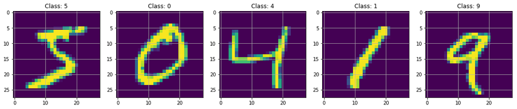

```python
# plot the first n images of the dataset
n = 5

dataset.plotDigits(X[:n], y[:n], n)
```

```python
# print information of the dataset
dataset.printInfo(y)
```

```
Class 0: 6903 elements
Class 1: 7877 elements
Class 2: 6990 elements
Class 3: 7141 elements
Class 4: 6824 elements
Class 5: 6313 elements
Class 6: 6876 elements
Class 7: 7293 elements
Class 8: 6825 elements
Class 9: 6958 elements
---------
```

## 3.0 Create two Model Objects - Only Digits and one for Characters

**Note**: Model takes as primarily argument a dataset object. Indeed, the provided instance is exploited in the case of a new train. As default option, model objects try always to load a pre-trained model from the dirBin folder. If not found, it is automatically performed a new training using the specified parameters (hyper-parameters).

```python
# create an object of the class Model
# no forced train and char False ---> load digits weights
model_digits = Model(mainDir, dataset, dirBin = 'bin', char=False,
              epochs = 20, batchSize = 128, train=False, verbose=True)
```

```python
# create an object of the class Model
# FORCED train and char True ---> train when characters classifier is launched
model_char = Model(mainDir, dataset, dirBin = 'bin', char=True,
              epochs = 100, batchSize = 128, train=True, verbose=True)
```

## 4.0 Create a Detector Object for Digits Classification

**Class Notes**: DigitClassificator loads a model object and performs the needed operations to properly prepare it for inference. Then two methods are available to predict characters from plain sheets or boxes with a specific dimension.

```python
media = 'media'
```

```python
# create an object of the class DigitClassificator
# the model will be model_digits
clf_digit = DigitClassificator(model_digits, verbose=True)
```

```
_________________________________________________________________
Layer (type)                 Output Shape              Param #
=================================================================
conv2d_138 (Conv2D)          (None, 28, 28, 32)        832
_________________________________________________________________
conv2d_139 (Conv2D)          (None, 28, 28, 32)        25632
_________________________________________________________________
max_pooling2d_69 (MaxPooling (None, 14, 14, 32)        0
_________________________________________________________________
dropout_101 (Dropout)        (None, 14, 14, 32)        0
_________________________________________________________________
conv2d_140 (Conv2D)          (None, 14, 14, 64)        18496
_________________________________________________________________
conv2d_141 (Conv2D)          (None, 14, 14, 64)        36928
_________________________________________________________________
max_pooling2d_70 (MaxPooling (None, 7, 7, 64)          0
_________________________________________________________________
dropout_102 (Dropout)        (None, 7, 7, 64)          0
_________________________________________________________________
flatten_34 (Flatten)         (None, 3136)              0
_________________________________________________________________
dense_68 (Dense)             (None, 256)               803072
_________________________________________________________________
dropout_103 (Dropout)        (None, 256)               0
_________________________________________________________________
dense_69 (Dense)             (None, 10)                2570
=================================================================
Total params: 887,530
Trainable params: 887,530
Non-trainable params: 0
_________________________________________________________________
```

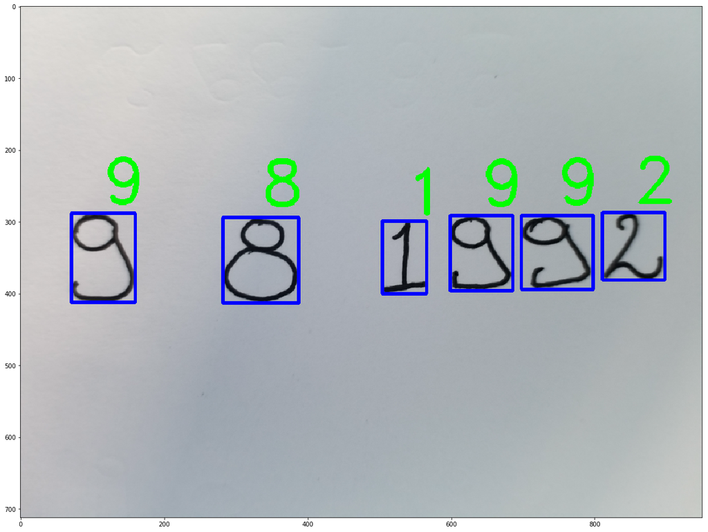

```python
# predict numbers on a plain sheet
clf_digit.predict(os.path.join(media, 'number_test.jpg'), char=False)
```

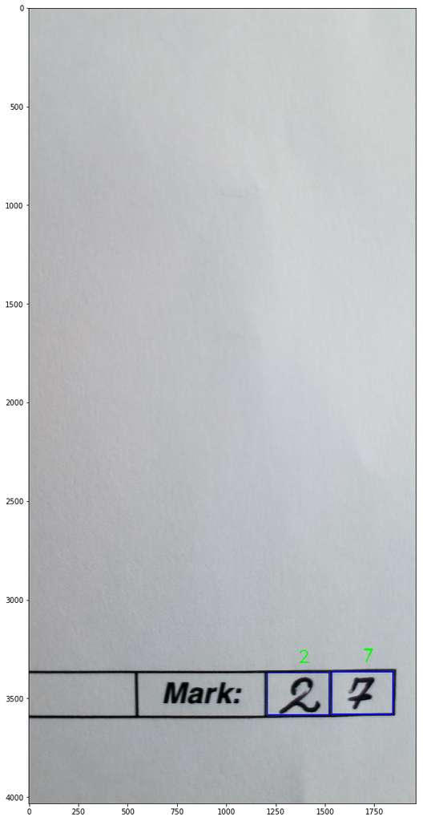

```python
# predict numbers on a sheet with boxes of a specific dimension
clf_digit.predictBoxes(os.path.join(media, 'boxes_test.jpg'), char=False)
```

## 5.0 Create a Detector Object for Character Classification

```
INFO:root:Train a new model
INFO:root:Downloading letters and digits from EMNIST repository
INFO:emnist:Cached file found at /home/vitto/.cache/emnist/emnist.zip.
INFO:emnist:Cached file found at /home/vitto/.cache/emnist/emnist.zip.
```

```
_________________________________________________________________
Layer (type)                 Output Shape              Param #
=================================================================
conv2d_1 (Conv2D)            (None, 28, 28, 32)        832
_________________________________________________________________
conv2d_2 (Conv2D)            (None, 28, 28, 32)        25632
_________________________________________________________________
max_pooling2d_1 (MaxPooling2 (None, 14, 14, 32)        0
_________________________________________________________________
dropout_1 (Dropout)          (None, 14, 14, 32)        0
_________________________________________________________________
conv2d_3 (Conv2D)            (None, 14, 14, 64)        18496
_________________________________________________________________
conv2d_4 (Conv2D)            (None, 14, 14, 64)        36928
_________________________________________________________________
max_pooling2d_2 (MaxPooling2 (None, 7, 7, 64)          0
_________________________________________________________________
dropout_2 (Dropout)          (None, 7, 7, 64)          0
_________________________________________________________________
flatten_1 (Flatten)          (None, 3136)              0
_________________________________________________________________
dense_1 (Dense)              (None, 256)               803072
_________________________________________________________________
dropout_3 (Dropout)          (None, 256)               0
_________________________________________________________________
dense_2 (Dense)              (None, 47)                12079
=================================================================
Total params: 897,039
Trainable params: 897,039
Non-trainable params: 0
_________________________________________________________________

Epoch 00023: ReduceLROnPlateau reducing learning rate to 0.0005000000237487257.

Epoch 00032: ReduceLROnPlateau reducing learning rate to 0.0002500000118743628.

Epoch 00036: ReduceLROnPlateau reducing learning rate to 0.0001250000059371814.

Epoch 00043: ReduceLROnPlateau reducing learning rate to 6.25000029685907e-05.

Epoch 00046: ReduceLROnPlateau reducing learning rate to 3.125000148429535e-05.

Epoch 00052: ReduceLROnPlateau reducing learning rate to 1.5625000742147677e-05.

Epoch 00057: ReduceLROnPlateau reducing learning rate to 1e-05.
```

```
INFO:root:Model saved in /home/vitto/Documents/Hard Skills/Python_lab_Project/bin
```

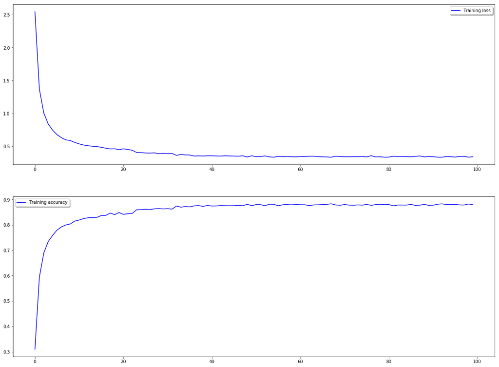

```python
# create an object of the class DigitClassificator
# the model will be model_char. Train is true and so a forced training is performed
clf_char = DigitClassificator(model_char, verbose=True)
```

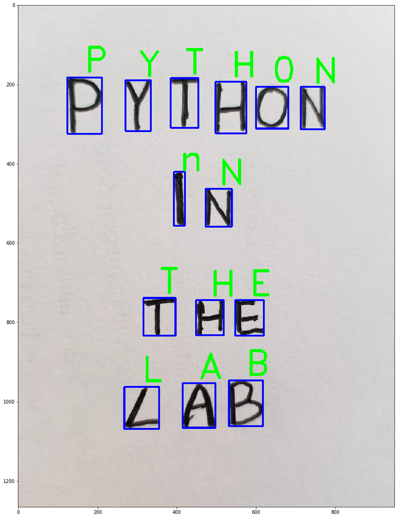

```python
# predict characters on a plain sheet
clf_char.predict(os.path.join(media, 'text_test.jpg'), char=True)
```

Almost perfect :)